# The Effect of Layovers on Airline Itinerary Market Fare in the United States

Adam Chapnik

10/14/2020

### ABSTRACT

People spend billions of dollars every year on domestic airplane flights in the U.S. I was therefore interested in what kinds of itineraries are the cheapest on average, since this knowledge could save a consumer hundreds or even thousands of dollars. A common assumption is that, all else being equal, an itinerary with more layovers is cheaper than a direct flight. I analyzed the Airline Origin and Destination Survey (DB1B) collected by the US Department of Transportation’s Bureau of Transportation Statistics, a random sample of ten percent of airline tickets sold by reporting carriers in the United States. Specifically, I focused on the dataset from all four financial quarters of 2017 since it was the most recent complete dataset. Given the hypothesis, I focused on how the number of layovers affected the market fare and fit a multiple variable linear regression model – including the number of layovers as a predictor – using stepwise variable selection based on BIC. My results showed that the cheapest flight itineraries have one or two layovers and have more passengers, although this changes at different market distance intervals. Still, there was so much variability in the data, and so many variables that I did not consider, that this result could be the result of important confounding variables that, once controlled for, reverse the association and make direct flights cheapest.

### INTRODUCTION

In the airplane itinerary market, there are many options offered by different flight operaters, who often coordinate with each other on the same itineraries to carry passengers. Fares of these itineraries vary, sometimes by a considerable amount. Some of the factors airline companies may take into consideration when pricing itineraries are the origins and destinations, the operating airline, the number of layovers, the total distance of the flight, the quarter of the year in which the flight took place, whether the flight was within the contiguous U.S. or not, and the number of passengers who purchased the same flight itinerary.

In this study, I used the Airline Origin and Destination Survey (DB1BMarket) https://www.transtats.bts.gov/Fields.asp [link]. This dataset focused on a random 10 percent sample of all itineraries that began and/or ended within the U.S in and its territories in 2017, collected by the U.S. Bureau of Transportation Statistics. To begin with, it was apparent that a large number of these observations were free. It ends up that airlines often need to transport flight crews between airports, and sometimes it is not possible for the crew to be put on a regular itinerary. I therefore assumed that these itineraries would not be generally available to the public for purchase and excluded them from the dataset. The dataset also contained a large number of observations with only one passenger. However, just because only one passenger purchased some itinerary does not mean that they were alone on all flights on that itinerary, since itineraries often contain several markets within them. Not only do itineraries with multiple layovers overlap with other itineraries with multiple layovers; a direct flight itinerary with only one passenger often is a subset of several other mutiple layover itineraries. Therefore, the only exclusion I made to the dataset was observations with a market fare of zero.

I expected to find, according to common sense, that more layovers made flights, in comparison to similar direct flights, cheaper. However, the data at first seemed to suggest that the more layovers in an itinerary, the more expensive the itinerary is, as shown in the below graph.

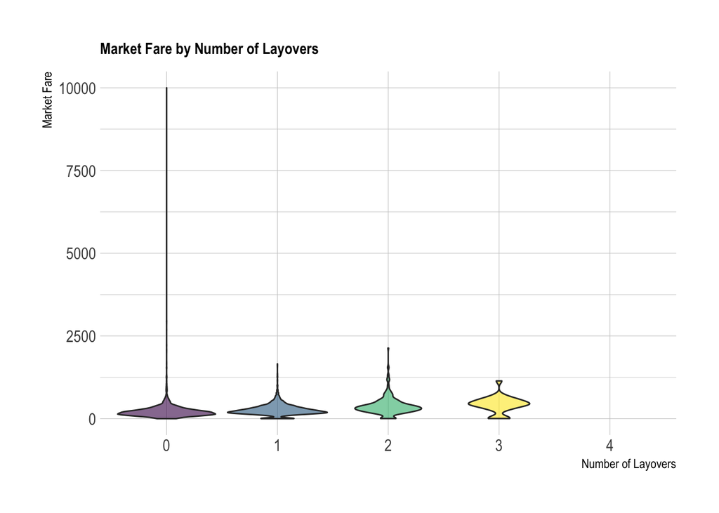

This seemed counterintuitive. I noticed that the market distance of the itinerary and the price of the itinerary were positively correlated. When controlling for the number of layovers, however, this relationship between market distance and market fare changes for each number of layovers. This can be seen in the below two graphs. Therefore, the above graph must actually be obscuring the confounding variable of market distance. That is, the market distance and number of layovers must have a close relationship. Theoretically, this makes sense, since planes can only fly so far, and once this barrier is reach they must make stops if passengers are to be carried any further. Thus, below that barrier there is more ability for carriers to substitute flights with layovers with direct flights, whereas above that barrier all flights must have layovers.

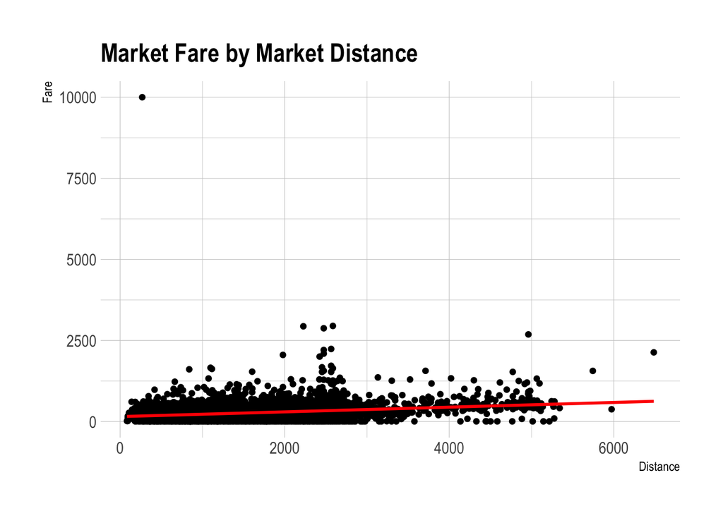

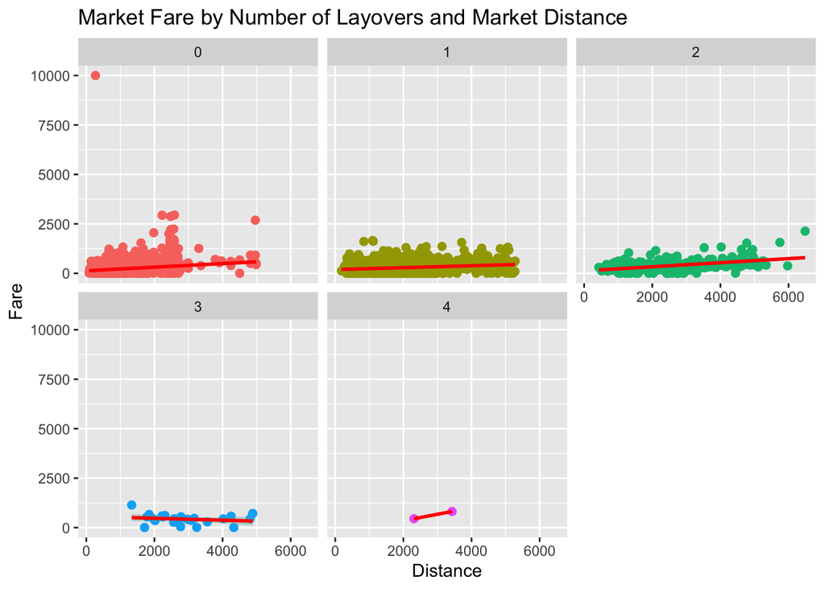

The above finding seemed to hint at the need for an interaction variable between market distance and number of layovers. This seemed reasonable, but further investigation could only be worthwhile if it was in fact possible for a consumer to substitute a direct flight for an itinerary which had the same origin and destination airports but at least one layovers. To evaluate this, I found a subset of the dataset consisting only of direct flights and their corresponding potential multi-legged itineraries. Any direct itineraries or multiple-legged itineraries which did not have such a corresponding itinerary were excluded from this graph. The resulting graph can be seen below.

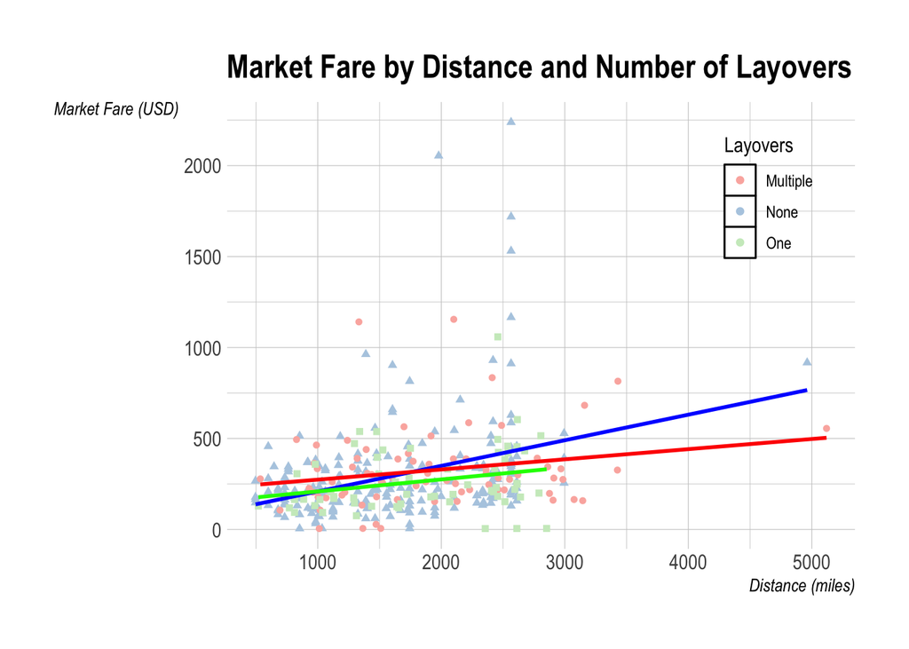

[figure not shown]

First of all, it should be noted that, out of the more than ten-thousand observations in this sample dataset, only 346 observations (3.46 percent) had a corresponding substitute. That substitutes are relatively hard to come by tells us at the very least that even considering these itinerary substitutions may often not be reasonable for a consumer to make. The potential for making a cheaper alternative might increase were a consumer willing to consider multiple-legged itineraries that do not originate and/or end at their airports of interest but still include stops at both their desired origin and destination airports in that order. However, from this dataset it is not possible for me to evaluate whether this would save a consumer money, since no observations in the dataset include a market fare for each leg of the itinerary, and it is unreasonable to assume that the market fare for a direct flight is the same for that respective leg of a multiple-legged itinerary, since being a direct flight likely is a factor in the market fare of a direct flight.

As we can see from this graph, longer flights are generally associated with a higher market fare. However, the specific association between the two changes with different numbers of layovers. The effect of a change in distance on market fare is greatest for direct flight, followed by itineraries with one layover, and is the least for itineraries with multiple layovers. Further, the intercept for each of these relationships is different. Thus, below some distance (here that is about 1,000 miles), direct flights are associated with cheaper market fare than flights with at least one layover. Above that distance, direct flights are associated with higher market fare than flights with only one layover; and above an even greater distance (about 1,800 miles), direct flights are associated with greater market fare than flights with any number of layovers. In addition, at some distance (about 2,800 miles) single-layover flights are no longer available, and the choices are either direct flights or flights with multiple layovers, with flights with multiple layovers being associated with a lower market fare.

Using this initial graph, we can see the final model does in fact have an interaction term between the number of layovers and the distance, and that this investigation is worthwhile, since so far the hypothesis seems to be true.

I chose to fit a multiple variable linear regression model to the dataset because the outcome I wanted to measure, itinerary fare, is continuous, and I also wanted to measure the influence of each variable on the outcome. In constructing the model, I used a stepwise selection method, using BIC in order to create a more parsimonius model than with AIC, since the sample size being used for processing purposes is relatively small. That is, I had to use a random sample with 10,000 observations from the dataset, since the original dataset was too large for R to process. Once I selected the terms for the model, I fit it to the larger dataset.

### METHOD

#### DATA COLLECTION

All the data was directly retrieved from the Bureau of Transportation Statistics, under the United States Department of Transportation. Therefore, the source was authoritative.

The data from the Bureau of Transportation Statistics was the only data used in this study. Because the sample data was randomly retrieved, the independence assumption was met.

#### MEASURE

For each case in the data, there are 12 variables collected.

The dependent variable for the analysis was the market fare of an itinerary, a continuous variable whose unit was dollars. It represents the price for a specific itinerary (ticket or set of tickets). The market distance was the only continuous independent variable.

There are 10 other variables in the data. The Origin (origin airport) is a distinctive alphabetical code assigned to each airport. The Destination (destination airport) is a distinctive alphabetical code assigned to each airport. The Origin and Destination State Name are alphabetical abbreviations for the origin and destination state of a itinerary. The Airport Group includes ordered alphabetical codes of the origin airport, destination airport, and layover airports (if the itinerary has layovers). The Operating Carrier Group includes alphabetical airline codes for the operating airline of each leg in an itinerary. The Passengers is the number of passengers who paid for the same itinerary during the same quarter. The quarter is the financial quarter during which the itinerary occured and is measured numeratively. The Itinerary Geographical Type is grouped into two categories, in which *1* refers to Non-contiguous Domestic Flights (includes Hawaii, Alaska and Territories) and *2* refers to Contiguous Domestic Flights (lower 48 states only). The Number of Layovers is measured numeratively, with *0* indicating a direct flight, *1* indicating one layover, etc.

#### DATA ANALYSIS

I constructed a multiple variable linear regression for average plane fare with the following characteristics: the financial quarter, the number of passengers who purchased the specific itinerary, the operating carrier on the first (or only) leg of the itinerary, and an interaction term between the market distance of the itinerary and the number of layovers on the itinerary. To arrive at these main effects, I started with a full model with all the possible variables, excluding origin and destination state abbreviations since those had clear multicollinearity with the origin and destination airports. This full model also included the interaction term between market distance and the number of layovers. I then iteratively added and deleted variables to the model based on BIC, utilizing a stepwise approach, since the smaller dataset caused the risk of overfitting, and therefore I need to make sure the model would be more parsimonius than with using AIC.

After determining the main effects (financial quarter, number of passengers, number of layovers, market distance, contiguity of the itinerary, origin operating carrier, and an interaction between market distance and number of layovers), I checked the VIF of the terms in order to limit multicollinearity.

|  | GVIF | Df | GVIF^(1/(2*Df)) |
| --- | --- | --- | --- |
| QUARTER | 1.016351 | 3 | 1.002707 |
| PASSENGERS | 1.044378 | 1 | 1.021948 |
| MARKET_DISTANCE | 3.673827 | 1 | 1.916723 |
| ITIN_GEO_TYPE | 1.625502 | 1 | 1.274952 |
| numLayovers | 6627.286109 | 4 | 3.003772 |
| ORIGIN_OP_CARRIER | 1.763286 | 33 | 1.008631 |
| MARKET_DISTANCE:numLayovers | 11977.630485 | 4 | 3.234420 |

I had to remove the number of layovers as an effect in order that for all terms VIF < 4.

|  | GVIF | Df | GVIF^(1/(2*Df)) |
| --- | --- | --- | --- |
| QUARTER | 1.015443 | 3 | 1.002557 |
| PASSENGERS | 1.036000 | 1 | 1.017841 |
| MARKET_DISTANCE | 2.866622 | 1 | 1.693110 |
| ITIN_GEO_TYPE | 1.565531 | 1 | 1.251212 |
| ORIGIN_OP_CARRIER | 1.646350 | 33 | 1.007583 |
| MARKET_DISTANCE:numLayovers | 2.676472 | 4 | 1.130955 |

I then checked that the model had a zero conditional mean, which, as can be seen by the horizontal line and random distribution in the below Residuals vs. Fitted graph, it did; and whether the residuals were normally distributed. As can be seen by their non-linear distribution in the Normal Q-Q graph, the residuals were not normally distributed, but since the sample was still relatively large, I assumed this was inevitable. However, the model was heteroskedastic, as can be seen by the Scale-Location graph below and the fact that the line has a positive slope and the points seem to have a pattern to their distribution.

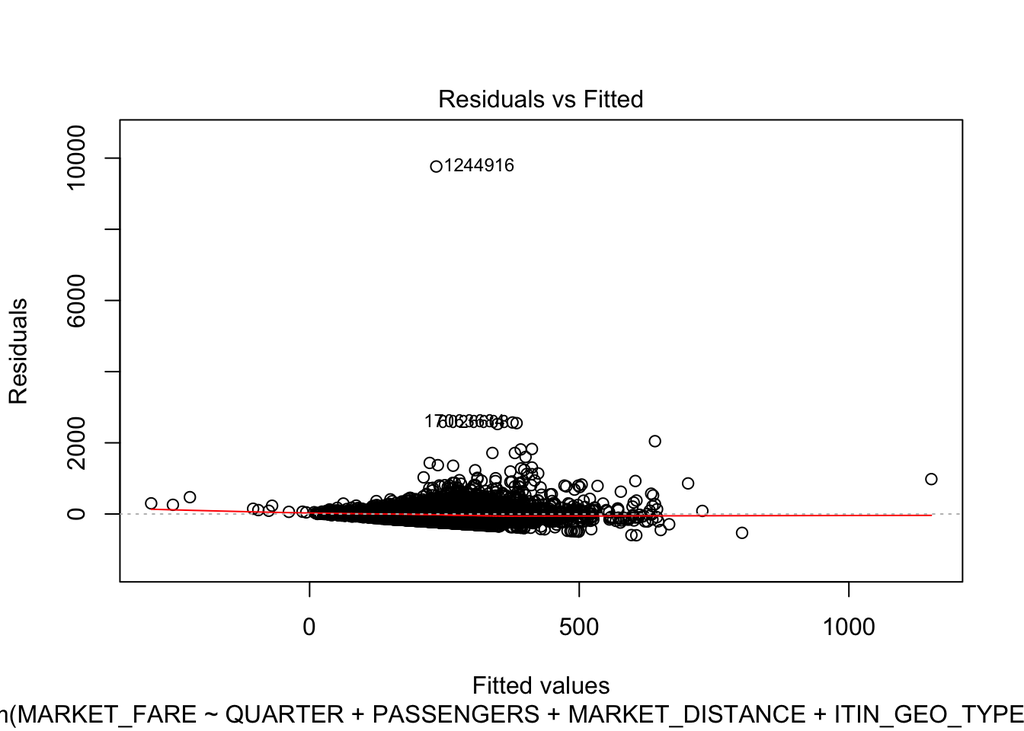

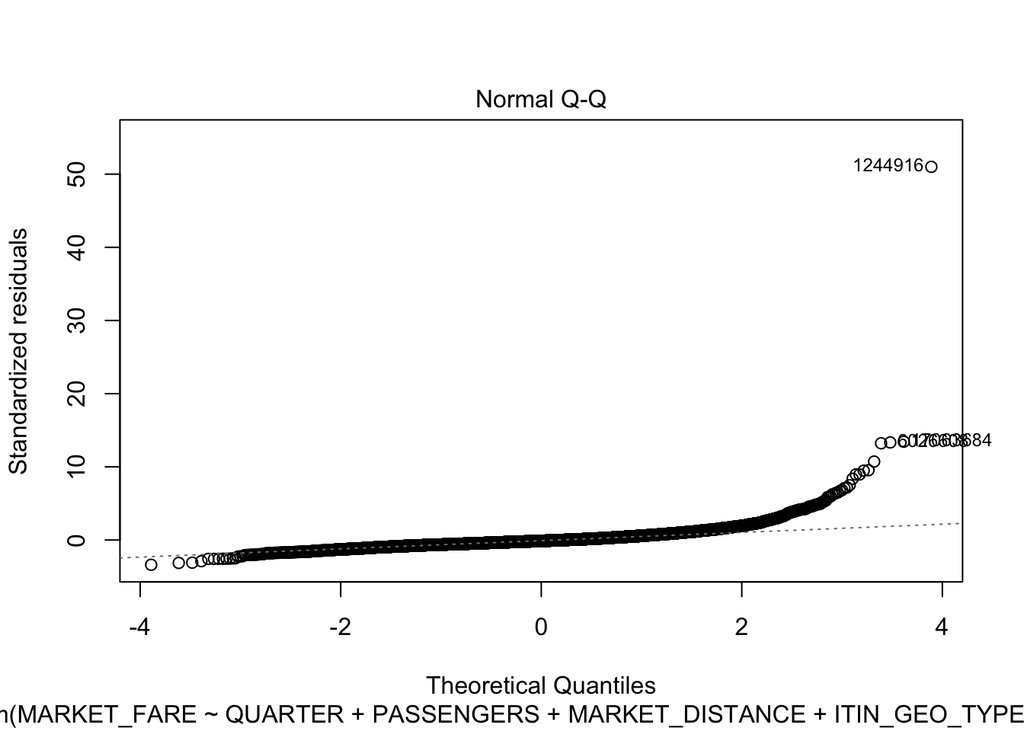

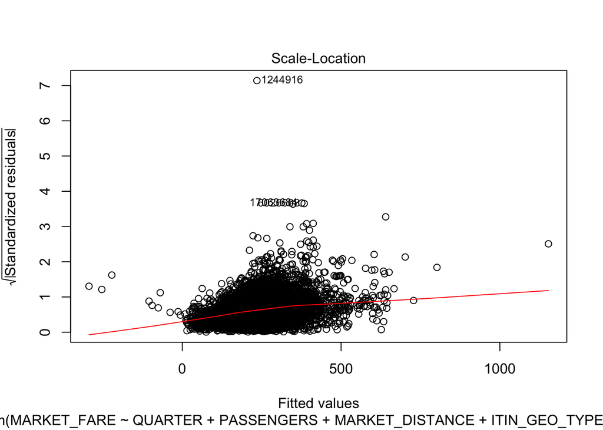

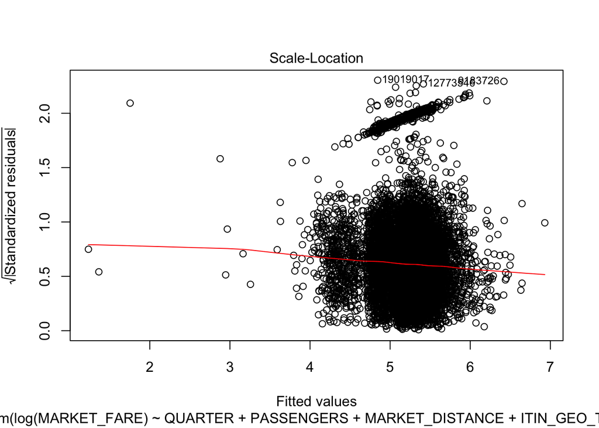

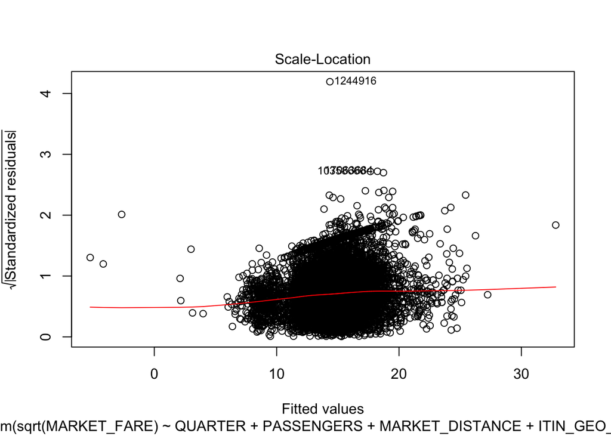

I then checked whether there were unusual points for the model. By calculating the Cook’s distance and standardized residual of each point in the dataset, I found there were a handful of unusual points which can be seen in the graph below. However, these observations seemed to be average itineraries on the whole. It is likely that they only appeared to be ususual points because of the sample from the dataset, so I left all points in the dataset.

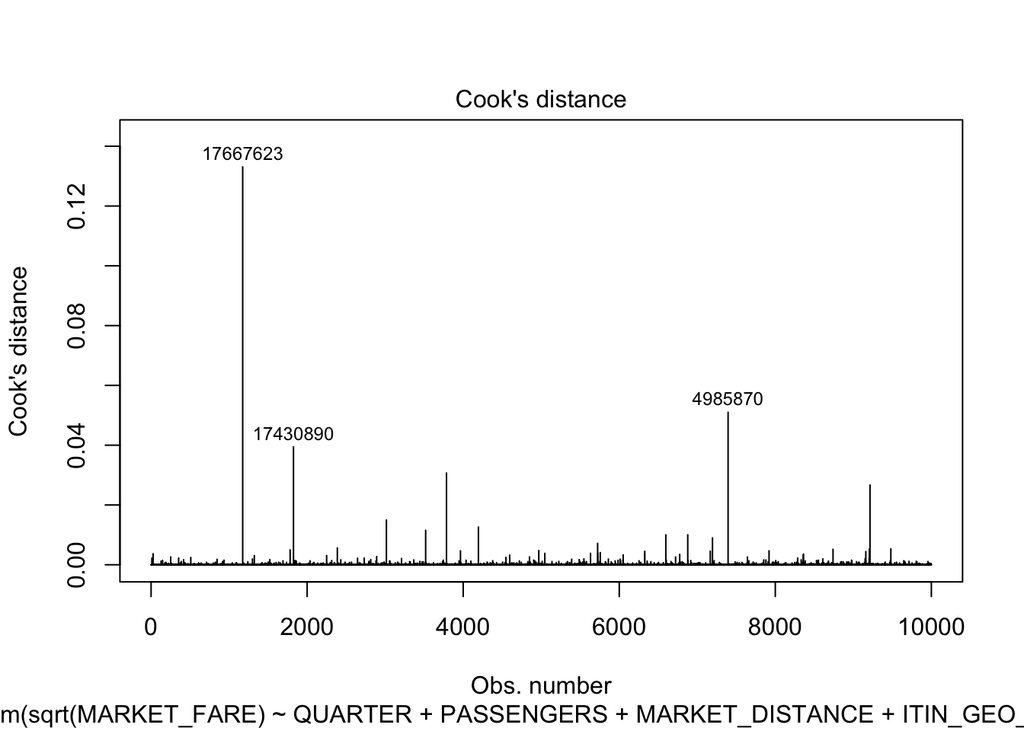

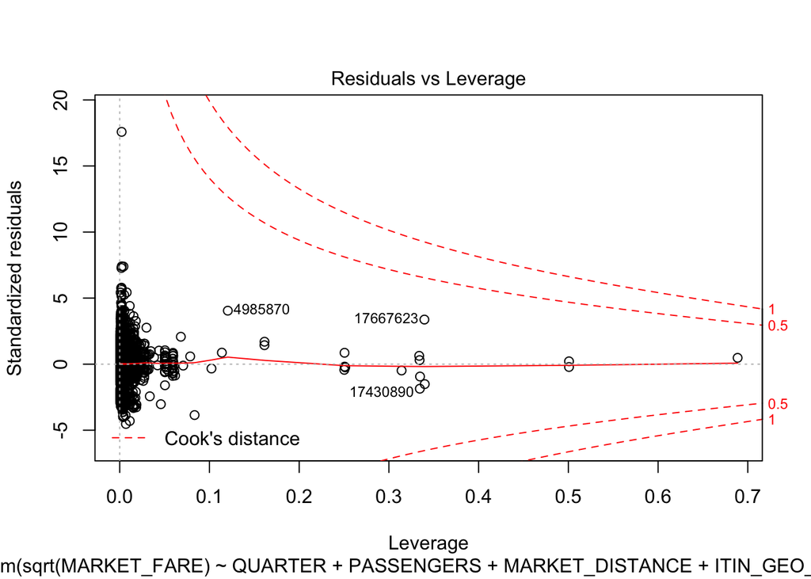

Finally, I checked that all the terms in the model were significant using an F-test. With this, I found that neither the contiguity of the itinerary nor the market distance were significant variables in the model, so I removed both terms in order to make the model as parsimonius as possible. This did not hurt the $R^2$ value.

This left me with the final, most parsimonius MLR with one flexible term that I could find. I then processed the model again, this time on as large a sample of the dataset as possible, which ended up being about 2,500,000 randomly selected observations, or a little less than 10 percent of the initial dataset.

### RESULTS

To better understand the model, the following is a graph of the market fare and its relationship to the interaction term between the market distance and number of layovers, with the number of layovers simplified into direct flights, itineraries with one layover, and itineraries with multiple layovers. According to the model, all else being equal, direct flights are most expensive, followed by itineraries with multiple layovers, and the cheapest flights have one layover. This result does, however, have several limitations which will be detailed in the Discussion section, and the model is slightly more complex.

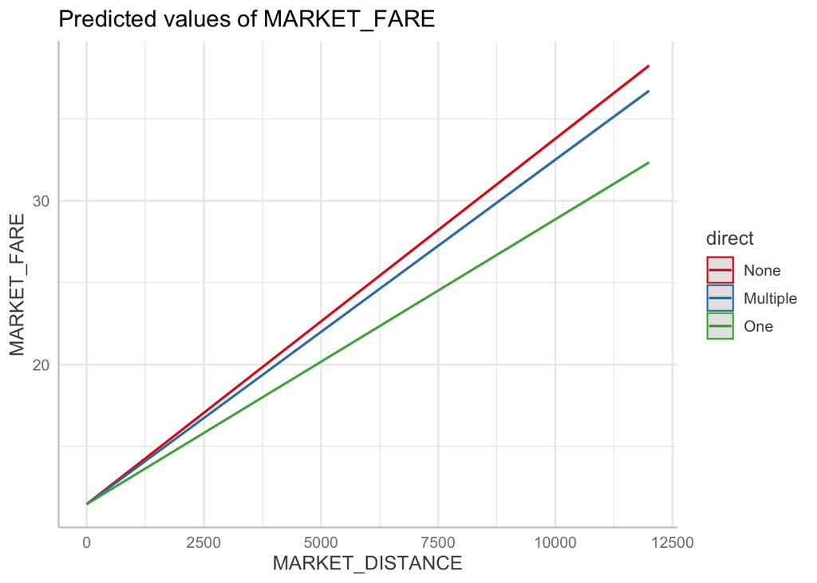

For starters, there exist thresholds in market distance above which the number of layovers of the itinerary necessarily increase, and itineraries with more than two layovers are not marginally equivalent. For example, the longest direct flight in the dataset is 5,095 miles, the longest itinerary with one layover is 8,763 miles, the longest itinerary with two layovers is 10,896 miles, and the longest itinerary with more than two layovers is 11,763 miles. This means that if a customer were looking for an itinerary that was 5,095 miles, they probably would have to purchase an itinerary with at least one layover. Therefore, below I have chunked the market distance accordingly into four separate graphs. Below 5,095 miles, and all else being equal, itineraries with one layover are associated with the lowest market fare, followed by itineraries with two layovers, then direct flights, and itineraries with more than two layovers are associated with the highest market fare. Between a market distance of 5,095 miles and 8,763 miles, and all else being equal, direct flights are unavailable. Itineraries with one layover are associated with the lowest market fare followed by those with two layovers. Between a market distance of 8,763 miles and 10,896 miles, and all else being equal, direct flights and itineraries with one layover are unavailable. Itineraries with two layovers are associated with the lowest market fare. Between a market distance of 10,896 miles and 11,763 miles, and all else being equal, direct flights and itineraries with one and two layovers are unavailable. Itineraries with seven layovers are associated with the lowest market fare, followed by those with three layovers.

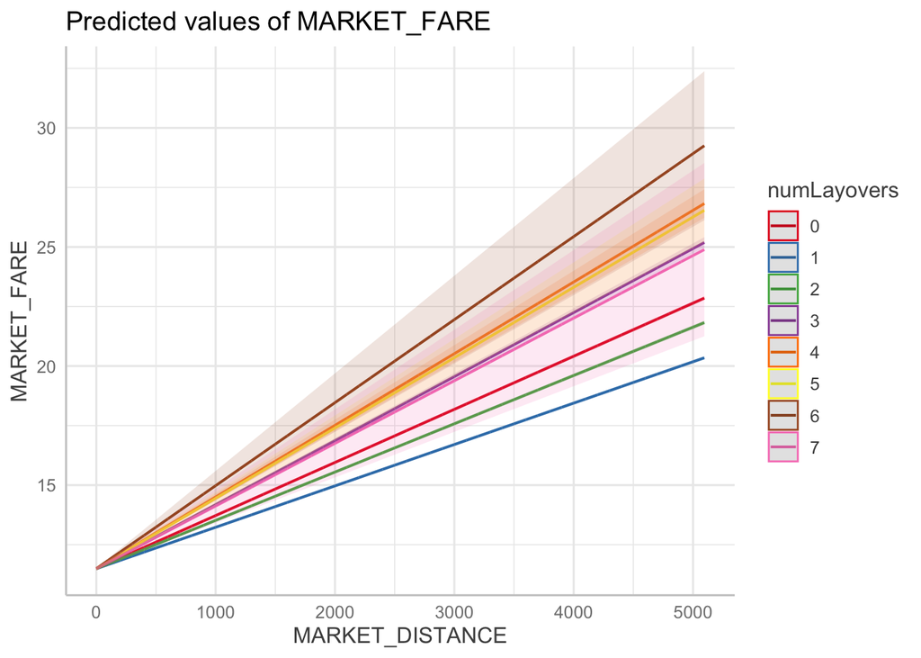

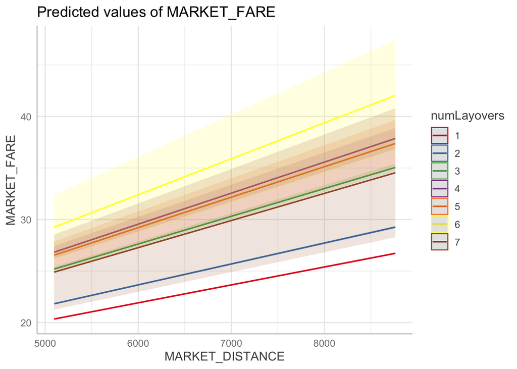

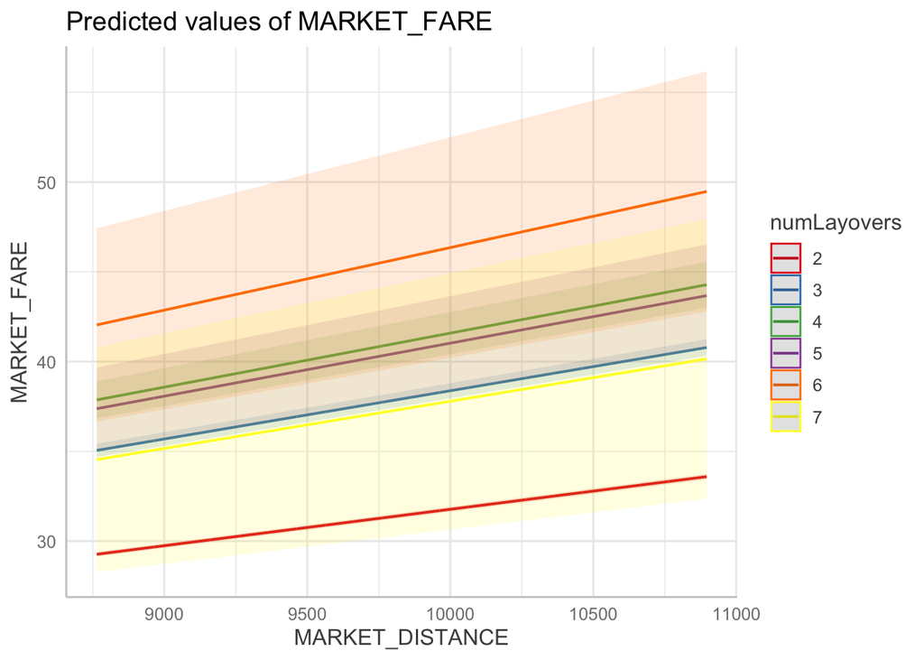

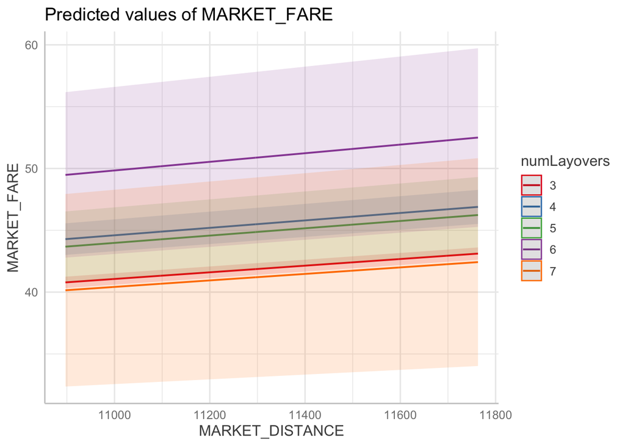

Here is a table of the coefficients, standard errors, t-statistics, and p-values for the model, excluding the terms for the origin operating carriers.

| term | estimate | std.error | statistic | p.value |
| --- | --- | --- | --- | --- |
| (Intercept) | 11.6477107 | 0.0350594 | 332.228087 | 0 |
| QUARTER2 | 0.3097553 | 0.0089158 | 34.742095 | 0 |
| QUARTER3 | -0.1485800 | 0.0090021 | -16.504980 | 0 |
| QUARTER4 | -0.1117703 | 0.0088348 | -12.651086 | 0 |
| PASSENGERS | -0.0746863 | 0.0005353 | -139.516259 | 0 |
| MARKET_DISTANCE:numLayovers0 | 0.0022300 | 0.0000060 | 372.451376 | 0 |
| MARKET_DISTANCE:numLayovers1 | 0.0017377 | 0.0000043 | 405.899687 | 0 |
| MARKET_DISTANCE:numLayovers2 | 0.0020280 | 0.0000072 | 280.102763 | 0 |
| MARKET_DISTANCE:numLayovers3 | 0.0026884 | 0.0000214 | 125.348231 | 0 |
| MARKET_DISTANCE:numLayovers4 | 0.0030094 | 0.0000597 | 50.445661 | 0 |
| MARKET_DISTANCE:numLayovers5 | 0.0029536 | 0.0001333 | 22.155857 | 0 |
| MARKET_DISTANCE:numLayovers6 | 0.0034860 | 0.0003133 | 11.126715 | 0 |
| MARKET_DISTANCE:numLayovers7 | 0.0026299 | 0.0003645 | 7.215586 | 0 |

$$E[sqrt(Market Fare)] = 11.6477107 - 0.0746863*passengers + 0.3097553*quarter_2 - 0.14858*quarter_3 - 0.1117703*quarter_4 + 0.00223marketdistance*numlayovers_0 + 0.0017377*marketdistance*numlayovers_1 + 0.002028*marketdistance*numlayovers_2 + 0.0026884*marketdistance*numlayovers_3 + 0.0030094*marketdistance*numlayovers_4 + 0.0029536*marketdistance*numlayovers_5 + 0.003486*marketdistance*numlayovers_6 + 0.0026299*marketdistance*numlayovers_7 + etcetera$$

$numlayovers_0 = 1$ if a flight is direct and $numlayovers_0 = 0$ if a flight is not direct. $numlayovers_1 = 1$ if a flight has one layover and $numlayovers_1 = 0$ if a flight does not have one layover. $quarter_2 = 1$ if a flight is during the second quarter and $quarter_2 = 0$ if a during the first quarter. *etcetera* represents all the coefficients and dummy terms for origin operating carrier that are too unweildly to be included in this equation. Those values are available in the Appendix.

The $R^2$ value for the model was 0.1915, and the adjusted $R^2$ was 0.1881. At best, this would mean that my model explains 19.15 percent of the variability in the market fare; and at worst, it explains 18.81 percent of the variability in the market fare.

Below is a table of the coefficients for the for the model, excluding the terms for the origin operating carriers, in percent change. Below that is a table of the 95% Confidence Intervals for those coefficients, also in percent change.

|  | x |
| --- | --- |
| (Intercept) | 2329.5421343 |
| QUARTER2 | 61.9510609 |
| QUARTER3 | -29.7159922 |
| QUARTER4 | -22.3540692 |
| PASSENGERS | -14.9372654 |
| MARKET_DISTANCE:numLayovers0 | 0.4460032 |
| MARKET_DISTANCE:numLayovers1 | 0.3475482 |
| MARKET_DISTANCE:numLayovers2 | 0.4056091 |
| MARKET_DISTANCE:numLayovers3 | 0.5376845 |
| MARKET_DISTANCE:numLayovers4 | 0.6018844 |
| MARKET_DISTANCE:numLayovers5 | 0.5907110 |
| MARKET_DISTANCE:numLayovers6 | 0.6972081 |
| MARKET_DISTANCE:numLayovers7 | 0.5259763 |

|  | 2.5 % | 97.5 % |
| --- | --- | --- |
| (Intercept) | 2315.7991033 | 2343.2851653 |
| QUARTER2 | 58.4561103 | 65.4460116 |
| QUARTER3 | -33.2447637 | -26.1872207 |
| QUARTER4 | -25.8172653 | -18.8908730 |
| PASSENGERS | -15.1471084 | -14.7274224 |
| MARKET_DISTANCE:numLayovers0 | 0.4436562 | 0.4483502 |
| MARKET_DISTANCE:numLayovers1 | 0.3458700 | 0.3492264 |
| MARKET_DISTANCE:numLayovers2 | 0.4027709 | 0.4084472 |
| MARKET_DISTANCE:numLayovers3 | 0.5292772 | 0.5460918 |
| MARKET_DISTANCE:numLayovers4 | 0.5784993 | 0.6252694 |
| MARKET_DISTANCE:numLayovers5 | 0.5384552 | 0.6429669 |
| MARKET_DISTANCE:numLayovers6 | 0.5743953 | 0.8200210 |
| MARKET_DISTANCE:numLayovers7 | 0.3831057 | 0.6688470 |

### DISCUSSION

It is worth noting, again, that the results of this study probably cannot be generalized to itineraries outside of the United States because all itineraries in this data pass through the United States. Furthermore, the model is only for one particular year, 2017, and therefore probably cannot be generalized to other years.

Still, there seem to be several limitations of this interpretation. First, the model does not have a term for market distance. Therefore, it is possible that market distance is actually a far better explanatory variable than number of layovers, and the apparent difference in market fare of itineraries with different numbers of layovers is actually a result of market distance being a confounding variable, especially since the number of layovers and the market distance are so closely linked. Considering that the change in market fare for changes in market distance for itineraries with different numbers of layovers is so small (especially comparies to the change in market fare for changes in the number of passengers who purchased the itinerary, for instance), it is likely that market distance alone has a far larger impact on market fare than number of layovers.

There are also other reasons to be cautious about the results of the model. For instance, the low explanatory power ($R^2 = 0.1915$) hints at the fact that there are probably many confounding variables and others than the model has not taken into consideration. The model accounts for market fare during different financial quarters, but market fare is also based on gas prices, which might completely account for the apparent differences in market fare each financial quarter plus more variability in market fare. It might be possible that a variable with more exact pinpointing of the date of purchase might also improve the explanatory power of the model. The travel class of seating, which is usually considered one of the most important factors that influence an itinerary’s price, is likely another confounding variable. Beyond that, however, I am not aware of potential factors that were left out of the model that could have increased its explanatory power.

The low explanatory power of the model mostly likely just comes down to the fact that MLRs can be very limited if the outcome is not exactly linear in the parameters. Although a more complex model may have shown better results, it would not have been able to answer the hypothesis for whatever this answer is worth.

### APPENDIX

Table of Coefficients in the Model

|  | x |
| --- | --- |
| (Intercept) | 2329.5421343 |
| QUARTER2 | 61.9510609 |
| QUARTER3 | -29.7159922 |
| QUARTER4 | -22.3540692 |
| PASSENGERS | -14.9372654 |
| ORIGIN_OP_CARRIER3M | 465.0777369 |
| ORIGIN_OP_CARRIER4B | 754.6191811 |
| ORIGIN_OP_CARRIER7H | 252.1578908 |
| ORIGIN_OP_CARRIER9E | 328.5450686 |
| ORIGIN_OP_CARRIER9K | 798.1083236 |
| ORIGIN_OP_CARRIERAA | 255.6474653 |
| ORIGIN_OP_CARRIERAS | -41.2430502 |
| ORIGIN_OP_CARRIERAX | 526.1470255 |
| ORIGIN_OP_CARRIERB6 | 14.9456866 |
| ORIGIN_OP_CARRIERBB | 608.4978410 |
| ORIGIN_OP_CARRIERC5 | 380.0851476 |
| ORIGIN_OP_CARRIERCP | 65.3961683 |
| ORIGIN_OP_CARRIERDL | 308.0922159 |
| ORIGIN_OP_CARRIEREM | -84.8012715 |
| ORIGIN_OP_CARRIEREV | 524.5778169 |
| ORIGIN_OP_CARRIERF9 | -942.2401122 |
| ORIGIN_OP_CARRIERG4 | -778.1105887 |
| ORIGIN_OP_CARRIERG7 | 407.8416189 |
| ORIGIN_OP_CARRIERH6 | 3007.8083411 |
| ORIGIN_OP_CARRIERHA | 375.1424283 |
| ORIGIN_OP_CARRIERKS | 1201.6655800 |
| ORIGIN_OP_CARRIERMQ | 456.8688770 |
| ORIGIN_OP_CARRIERMW | 528.3172540 |
| ORIGIN_OP_CARRIERNK | -987.2271649 |
| ORIGIN_OP_CARRIEROH | 422.8485617 |
| ORIGIN_OP_CARRIEROO | 385.7102527 |
| ORIGIN_OP_CARRIERPT | 440.9084833 |
| ORIGIN_OP_CARRIERQX | -66.0916195 |
| ORIGIN_OP_CARRIERSY | -133.8013473 |
| ORIGIN_OP_CARRIERUA | 383.1877159 |
| ORIGIN_OP_CARRIERVX | -52.6382213 |
| ORIGIN_OP_CARRIERWN | -96.3516660 |
| ORIGIN_OP_CARRIERWP | -142.9841839 |
| ORIGIN_OP_CARRIERYV | 447.4317403 |
| ORIGIN_OP_CARRIERYX | 320.8313134 |
| ORIGIN_OP_CARRIERZK | 1157.7202672 |
| ORIGIN_OP_CARRIERZW | 416.0721247 |
| MARKET_DISTANCE:numLayovers0 | 0.4460032 |
| MARKET_DISTANCE:numLayovers1 | 0.3475482 |
| MARKET_DISTANCE:numLayovers2 | 0.4056091 |
| MARKET_DISTANCE:numLayovers3 | 0.5376845 |
| MARKET_DISTANCE:numLayovers4 | 0.6018844 |
| MARKET_DISTANCE:numLayovers5 | 0.5907110 |
| MARKET_DISTANCE:numLayovers6 | 0.6972081 |
| MARKET_DISTANCE:numLayovers7 | 0.5259763 |

Table of Confidence Intervals for Parameters in the model

|  | 2.5 % | 97.5 % |
| --- | --- | --- |
| (Intercept) | 2315.7991033 | 2343.2851653 |
| QUARTER2 | 58.4561103 | 65.4460116 |
| QUARTER3 | -33.2447637 | -26.1872207 |
| QUARTER4 | -25.8172653 | -18.8908730 |
| PASSENGERS | -15.1471084 | -14.7274224 |
| ORIGIN_OP_CARRIER3M | 384.5181488 | 545.6373250 |
| ORIGIN_OP_CARRIER4B | 446.6002237 | 1062.6381385 |
| ORIGIN_OP_CARRIER7H | 143.5686458 | 360.7471357 |
| ORIGIN_OP_CARRIER9E | 312.7894090 | 344.3007281 |
| ORIGIN_OP_CARRIER9K | 725.1601069 | 871.0565402 |
| ORIGIN_OP_CARRIERAA | 241.8897294 | 269.4052011 |
| ORIGIN_OP_CARRIERAS | -56.3747697 | -26.1113308 |
| ORIGIN_OP_CARRIERAX | 503.1542391 | 549.1398120 |
| ORIGIN_OP_CARRIERB6 | -0.1520560 | 30.0434292 |
| ORIGIN_OP_CARRIERBB | 466.9561182 | 750.0395639 |
| ORIGIN_OP_CARRIERC5 | 349.0614273 | 411.1088680 |
| ORIGIN_OP_CARRIERCP | 46.7918425 | 84.0004941 |
| ORIGIN_OP_CARRIERDL | 294.3925322 | 321.7918996 |
| ORIGIN_OP_CARRIEREM | -200.4268943 | 30.8243513 |
| ORIGIN_OP_CARRIEREV | 509.1796586 | 539.9759751 |
| ORIGIN_OP_CARRIERF9 | -959.2465855 | -925.2336390 |
| ORIGIN_OP_CARRIERG4 | -794.6627342 | -761.5584433 |
| ORIGIN_OP_CARRIERG7 | 389.5640913 | 426.1191465 |
| ORIGIN_OP_CARRIERH6 | 1085.8531764 | 4929.7635058 |
| ORIGIN_OP_CARRIERHA | 356.4945240 | 393.7903326 |
| ORIGIN_OP_CARRIERKS | 1106.3950257 | 1296.9361343 |
| ORIGIN_OP_CARRIERMQ | 440.9106151 | 472.8271390 |
| ORIGIN_OP_CARRIERMW | -26.6138413 | 1083.2483493 |
| ORIGIN_OP_CARRIERNK | -1003.1941448 | -971.2601851 |
| ORIGIN_OP_CARRIEROH | 407.3091525 | 438.3879710 |
| ORIGIN_OP_CARRIEROO | 371.4588920 | 399.9616134 |
| ORIGIN_OP_CARRIERPT | 420.0108102 | 461.8061563 |
| ORIGIN_OP_CARRIERQX | -84.1525416 | -48.0306973 |
| ORIGIN_OP_CARRIERSY | -163.1710086 | -104.4316860 |
| ORIGIN_OP_CARRIERUA | 369.2455013 | 397.1299306 |
| ORIGIN_OP_CARRIERVX | -71.1102690 | -34.1661737 |
| ORIGIN_OP_CARRIERWN | -110.0817796 | -82.6215524 |
| ORIGIN_OP_CARRIERWP | -208.0371522 | -77.9312155 |
| ORIGIN_OP_CARRIERYV | 431.5309867 | 463.3324939 |
| ORIGIN_OP_CARRIERYX | 305.6127544 | 336.0498724 |
| ORIGIN_OP_CARRIERZK | 992.3875010 | 1323.0530334 |
| ORIGIN_OP_CARRIERZW | 395.7665222 | 436.3777272 |
| MARKET_DISTANCE:numLayovers0 | 0.4436562 | 0.4483502 |
| MARKET_DISTANCE:numLayovers1 | 0.3458700 | 0.3492264 |
| MARKET_DISTANCE:numLayovers2 | 0.4027709 | 0.4084472 |
| MARKET_DISTANCE:numLayovers3 | 0.5292772 | 0.5460918 |
| MARKET_DISTANCE:numLayovers4 | 0.5784993 | 0.6252694 |
| MARKET_DISTANCE:numLayovers5 | 0.5384552 | 0.6429669 |
| MARKET_DISTANCE:numLayovers6 | 0.5743953 | 0.8200210 |
| MARKET_DISTANCE:numLayovers7 | 0.3831057 | 0.6688470 |